# 검정 및 회귀분석 실습

## 모듈 소개

### 1. scipy

- 확률밀도를 구하기 위한 모듈이다.
- import scipy 라는 명령어를통해 scipy 패키지를 불러오면, 패키지에 내장되어 있는 다양한 모듈 및 함수를 사용할 수 있다.
- 여러 가지 통계 함수를 불러올 수 있는 모듈로는 scipy 패키지 안의 stats 모듈이 있다.
- scipy.stats 패키지 안의 함수로 여러가지 분포함수들을 사용할 수 있다. (강의에 사용될 분포함수에는 binom, uniform, norm, chi2, t, f 등이 있다.)
- python 에서는 패키지 안의 세부 모듈들을 따로 불러올 수 있다. 예를 들어, 이항분포 모듈을 불러오기 위해서는 from scipy.stats import binom 이라는 명령어를 사용한다. 이 명령어를 통해서 binom 모듈 안에 있는 이항분포의 다양한 함수들을 편리하게 사용할 수 있다.

### 2. numpy

- 벡터, 행렬 등의 표현 및 계산을 위해서는 numpy 패키지가 필요하다.
- 강의에는 주로 수의 제곱근형태(sqrt), 수열(arange), 나열(array),올림(ceil) 이나 집단의 평균(mean), 분산(var), 표준편차(std) 등을 구하는 데에 주로 사용된다.
- import numpy as np 명령어를 통해서 numpy 패키지를 np라는 오브젝트에 저장한다.

### 3. matplotlib

- scipy 모듈 함수와 matplotlib 패키지의 pyplot 모듈을 이용해 이항분포 확률밀도함수를 그릴 수 있다.
- import matplotlib.pyplot as plt 명령어는 matplotlib 패키지의 pyplot 모듈을 plt라는 오브젝트에 저장하는 명령어이다.
- pyplot 모듈 내부의 함수 plot을 사용할 때, matplotlib.pyplot.plot() 명령어 대신 plt.plot()라는 명령어를 사용할 수 있다.
- pyplot 모듈과 관련된 함수와 옵션들은 다음과 같다.
- https://matplotlib.org/gallery/index.html : 다양한 차트 예시 참고

| 함수 | 설명 |
| --- | --- |
| figure() | matplotlib 에서 그래프가 들어가는 영역을 의미한다. |
| plot() | 그래프를 그려준다. |
| subplots() | subplot들을 포함하는 figure를 생성해준다. |
| legend() | 범례를 그려준다. |
| show() | 그래프를 화면에 보여준다. |
| xlabel() | x축에 라벨을 출력한다. |
| ylabel() | y축에 라벨을 출력한다. |
| title() | 타이틀을 출력한다. |
| xlim() | x축의 상한/하한 값을 설정한다. |
| ylim() | y축의 상한/하한 값을 설정한다. |
| subplot() | subplot을 지정한다. |

## 분포 소개

1) 확률분포(probability distribution) : 확률변수 X가 가질 수 있는 값과 해당하는 확률에 대해 나타낸 것
$$Pr(a<x<b)=\int_{a}^{b}f(x)dx$$

2) 기대값(expected value) :

- $\mu=E(X)=\int_{-\infty}^{\infty}xf(x)dx$

3) 분산(varianve)과 표준편차(standard deviation) :

- $Var(X)=E[(X-\mu)^2]=E(X^2)-[E(X)]^2$
- $sd(X)=\sqrt{Var(X)}$

4) 이항분포 :$X\sim B(n,p)$

- $X_1,X_2,\dots,X_n$은 서로 독립이고, 각각 성공률이 p인 베르누이 확률변수
- $X=X_1+X_2+\dots,+X_n$은 성공률이 p인 베르누이 시행을 n번 반복시행한 결과로 X는 n번 시행할 때의 성공횟수이다.
- $f(x)=\binom{n}{x}p^x(1-p)^{n-x}$

5) 균일분포 : $X \sim U(a,b)$

- 확률변수 X가 a와 b사이에서 동일한 값을 가질 때 X를 균일분포를 따른다고 한다.
- $f(x)=\frac{1}{b-a},a<x<b$

6) 정규분포 : $X \sim N(\mu,\sigma^2)$

- 평균과 표준편차에 의해 결정되는 분포로 종형의 확률밀도함수를 갖는다.
- $f(x)=\frac{1}{\sqrt{2\pi\sigma^2}}exp(-\frac{(x-\mu)^2}{2\sigma^2})$

7) 카이제곱분포 : $\sum_{i=1}^{k}Z_i^2\sim \chi^2(k)$

- 확률변수 $Z_1,Z_2,\dots,Z_k$ 이 정규분포 $N(0,1)$로부터 추출한 k개의 랜덤표본일 때, $V=Z_1^2+Z_2^2\dots+Z_k^2$ 의 분포를 자유도 k인 카이제곱분포라고 한다.
- 정규분포 $N(\mu,\sigma^2)$로부터 추출한 n개의 랜덤표본 $X_1,X_2,\dots,X_n$ 의 표본분산 $S^2=\frac{1}{n-1}\sum_{i=1}^{n}(X_i-\bar{X})^2$ 에 대해 다음이 성립한다.

$$\frac{(n-1)S^2}{\sigma^2} \sim \chi^2(n-1)$$

8) t분포 : $T \sim t(k)$

- 표준정규분포를 따르는 확률변수를 Z라 하고, 이와는 독립이며 자유도가 k인 카이제곱분포를 따르는 확률변수를 V라고 할 때, $T=\frac{Z}{\sqrt{V/k}}$ 의 분포를 자유도가 k인 t분포라고 한다.
- $X_1,X_2,\dots,X_k$ 이 정규분포 $N(\mu,\sigma^2)$를 따르는 정규모집단에서 추출한 랜덤표본일 때, 스튜던트화된 표본평균의 분포가 다음과 같다.

$$\frac{\bar{X}-\mu}{S/\sqrt{n}} \sim t(n-1)$$

scipy.stats.binom.pmf(x,n,p) : scipy 패키지만 불러온 경우

binom.pmf(x,n,p) : scipy.stats 에서 binom 모듈을 따로 불러온 경우

### 이항분포의 확률밀도 - binom.pmf(x,n,p)

- x:이항분포를 따르는 확률변수값

  n:이항분포에서의 총 베르누이 시행횟수

  p:베르누이 시행 시 성공확률
- $X\sim B(n,p)$ 일 때, $Pr(X=x)={{n}\choose{x}}P^x (1-P)^{n-x}$의 값을 구한다.

### 이항분포의 누적확률 - binom.cdf(k,n,p)

- k:0부터 k까지의 누적확률을 구한다.
- $X \sim B(n,p)$일 때, $Pr(X\leq k)=\sum_{i=0}^{k}{{n}\choose{i}}P^i(1-P)^{n-i}$의 값을 구한다.

### 이항분포의 백분위수 - binom.ppf(q,n,p)

- q:구하고 싶은 분위수
- $X \sim B(n,p)$일 때, $Pr(X\leq x)=q$인 x의 값을 구한다.

### 이항분포의 난수생성 - binom.rvs(n,p,size)

- size:구하고 싶은 난수의 개수
- $X \sim B(n,p)$에서 'size'개의 난수를 생성한다.

```python
### 어느 제품의 불량률은 10% 이다. 임의의 5개의 제품 중에 불량품이 3개일 확률은?
import scipy
from scipy.stats import binom

print(round(binom.pmf(3,5,0.1),4))
# round(수,자릿수):반올림함수

### 어느 제품의 불량율은 10%이다. 임의의 20개의 제품 중에 불량품이 5개 이하일 확률은?
print(round(binom.cdf(k=5,n=20,p=0.1),4))
# print 함수는 강의자료에서 여러 결과를 나타내기 위해 사용한 것으로 생략 가능하다.

## 불랑품이 4개 이상일 확률은?
print(round(1-binom.cdf(k=3,n=20,p=0.1),4))
```

```
0.0081
0.9887
0.133
```

```python
print(binom.ppf(q=0.1875,n=5,p=0.5))

print(binom.rvs(5,0.5,size=3))
# size 옵션은 꼭 명시해주어야 한다.
```

```
1.0
[2 2 3]
```

```python
# bernoulli 모듈
from scipy.stats import bernoulli

print(bernoulli.pmf(1, 0.3))
print(binom.pmf(1, 1, 0.3))
```

```
0.3
0.3
```

이항분포와 마찬가지로 from scipy.stats import uniform 을 통해 균일분포 함수들을 사용할 수 있다. python에서는 location 변수와 scale 변수를 통해 Uniform(loc,loc+scale)의 형태로 균일분포를 표현한다. $X \sim U(a,b)$ 와 같이 표현한다.

### 균일분포의 확률밀도 - uniform.pdf(x,loc,scale)

- x:균일분포를 따르는 확률변수값
- loc:균일분포에서 하한값(a)
- sclae:균일분포에서 상한값-하한값(b-a)

### 균일분포의 누적확률 - uniform.cdf(x,loc,scale)

- x:여기서의 x 값은 확률변수값 x까지의 누적확률을 구한다는 의미이다.

### 균일분포의 백분위수 - uniform.ppf(q,loc,scale)

- q:구하고 싶은 분위수

### 균일분포의 난수생성 - uniform.rvs(loc,scale,size)

- size: $X \sim U(a,b)$에서 size개의 난수를 생성한다.

```python
from scipy.stats import uniform

print(uniform.pdf(x=1,loc=0,scale=2))

print(uniform.cdf(x=1,loc=0,scale=2))

print(uniform.ppf(q=0.3,loc=0,scale=2))

print(uniform.rvs(loc=0,scale=2,size=2))
```

```
0.5
0.5
0.6
[1.69089124 0.69909498]
```

from scipy.stats import norm을 통해 정규분포 함수들을 사용할 수 있다.

### 정규분포의 확률밀도 - norm.pdf(x,loc,scale)

- x:정규분포를 따르는 확률변수값
- loc: 평균($\mu$), scale: 표준편차($\sigma$)

### 정규분포의 누적확률 - norm.cdf(x,loc,scale)

- $X \sim N(\mu,\sigma^2)$의 확률밀도함수 $P(X \leq x)$의 값을 구한다.

### 정규분포의 백분위수 - norm.ppf(q,loc,scale)

- $X \sim N(\mu,\sigma^2)$일 때, $P(X \leq x)=q$를 만족하는 x의 값을 구한다.

### 정규분포의 난수생성 - norm.rvs(loc,scale,size)

- size개 만큼의 난수를 생성한다.

```python
from scipy.stats import norm

print(round(norm.pdf(x=0,loc=0,scale=1),3))

print(round(norm.cdf(x=0,loc=0,scale=1),3))

### 한 공장에서는 철근을 자르는데, 그 개별 길이가 평균 200cm, 표준편차 2cm이라고 한다. 철근의 개별 측정은 평균 주위로
### 정규분포를 따른다고 할 때, 무작위로 추출한 철근의 길이가 201cm 이상일 확률을 구하여라.
print(round(1-norm.cdf(x = 201, loc = 200, scale = 2), 4))
print(round(1-norm.cdf(x = 1/2, loc = 0, scale = 1), 4))

## 표본크기 25의 표본을 한 번 추출할 때, 이 표본의 평균길이가 201cm 이상일 확률은?
print(round(1-norm.cdf(x = 201, loc = 200, scale = 0.4), 4))
```

```
0.399
0.5
0.3085
0.3085
0.0062
```

```python
### 정규분포의 확률밀도함수 그리기

import numpy as np
import matplotlib.pyplot as plt
x=np.arange(-5,5.1,0.1)
# -5부터 5까지 0.1 간격의 수열(5.1은 저장되지 않음)

fx=norm.pdf(x=x,loc=0,scale=1)

def showplot():
    plt.plot(x,fx)

    plt.xlabel("x")
    # x좌표 이름
    plt.ylabel("fx")
    #y좌표 이름
    plt.title("pdf of standard normal dist")
    # 제목
```

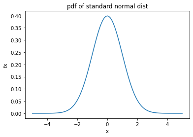

```python
showplot()
```

from scipy.stats import chi2 코드를 이용하여 카이제곱분포 함수들을 사용할 수 있다.

### 카이제곱분포의 확률밀도 - chi2.pdf(x,df)

- x : 카이제곱분포를 따르는 확률변수값
- df : 자유도

### 카이제곱분포의 누적확률 - chi2.cdf(x,df)

- $X \sim \chi^{2}(df)$의 확률밀도함수 $P(X \leq x)$의 값을 구한다.

### 카이제곱분포의 백분위수 - chi2.ppf(q,df)

- $X \sim \chi^{2}(df)$일 때, $P(X \leq x)=q$를 만족하는 x의 값을 구한다.

### 카이제곱분포의 난수생성 - chi2.rvs(df,size)

- size개 만큼의 난수를 생성한다.

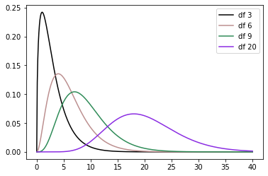

```python
from scipy.stats import chi2

x=np.arange(0,40.1,0.1)

plt.plot(x,chi2.pdf(x,3), color='black', label='df 3')
plt.plot(x,chi2.pdf(x,6),color='rosybrown', label='df 6')
plt.plot(x,chi2.pdf(x,9),color='seagreen', label='df 9')
plt.plot(x,chi2.pdf(x,20),color='blueviolet', label='df 20')

plt.legend(loc='upper right')
#우측 상단에 범례
# plt.plot의 label 옵션을 통해 범례에 사용할 선의 이름을 지정할 수 있다.
```

from scipy.stats import t 코드를 이용하여 t분포 함수들을 사용할 수 있다.

### t분포의 확률밀도 - t.pdf(x,df)

- x : t분포를 따르는 확률변수값
- df : 자유도

### t분포의 누적확률 - t.cdf(x,df)

- $X \sim t(df)$의 확률밀도함수 $P(X \leq x)$의 값을 구한다.

### t분포의 백분위수 - t.ppf(q,df)

- $X \sim t(df)$일 때, $P(X \leq x)=q$를 만족하는 x의 값을 구한다.

### t분포의 난수생성 - t.rvs(df,size)

- size개 만큼의 난수를 생성한다.

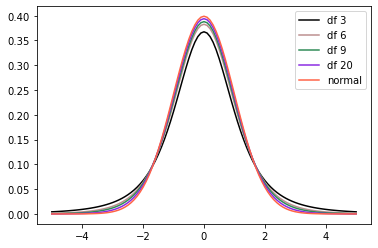

```python
from scipy.stats import t

x=np.arange(-5,5.1,0.1)

plt.plot(x,t.pdf(x,3), color='black', label='df 3')
plt.plot(x,t.pdf(x,6),color='rosybrown', label='df 6')
plt.plot(x,t.pdf(x,9),color='seagreen', label='df 9')
plt.plot(x,t.pdf(x,20),color='blueviolet', label='df 20')
plt.plot(x,norm.pdf(x,0,1),color='tomato', label='normal')

plt.legend(loc='upper right')
# 우측 상단에 범례
#plt.plot의 label 옵션을 통해 범례에 사용할 선의 이름을 지정할 수 있다.
```

```python
print(round(t.ppf(0.025, 5), 4))
print(round(t.ppf(0.025, 20), 4))
print(round(t.ppf(0.025, 100), 4))
print(round(t.ppf(0.025, 500), 4))
print(round(norm.ppf(0.025), 4))
```

```
-2.5706
-2.086
-1.984
-1.9647
-1.96
```

# 4장. 통계적 추론

## review...

1) 모평균에 관한 유의성 검정(모분산을 아는 경우)

- 가설 $H_0 : \mu=\mu_0$
- 검정통계량 $Z=\frac{\bar{X}-\mu_0}{\sigma/\sqrt{n}} \sim N(0,1)$ under $H_0$, 관측값=$z_0$

| $H_1$ | 유의확률 | 기각역 |
| --- | --- | --- |
| $\mu>\mu_0$ | $P=P(Z>z_0)$ | $Z> z_{1-\alpha}$ |
| $\mu<\mu_0$ | $P=P(Z<z_0)$ | $Z< -z_{1-\alpha}$ |
| $\mu\neq \mu_0$ | $P=P(\lvert Z\rvert>\vert z_0\vert)$ | $\lvert Z \rvert> z_{1-\alpha/2}$ |

2) 모평균에 관한 유의성 검정(모분산을 모르는 경우)

- 가설 $H_0 : \mu=\mu_0$
- 검정통계량 $T=\frac{\bar{X}-\mu_0}{S/\sqrt{n}}\sim t(n-1)$ under $H_0$, 관측값=$t_0$

| $H_1$ | 유의확률 | 기각역 |
| --- | --- | --- |
| $\mu>\mu_0$ | $P=P(T>t_0)$ | $T> t_{1-\alpha}(n-1)$ |
| $\mu<\mu_0$ | $P=P(T<t_0)$ | $T< -t_{1-\alpha}(n-1)$ |
| $\mu\neq \mu_0$ | $P=P(\lvert T \rvert>\lvert t_0 \rvert)$ | $\lvert T\rvert> t_{1-\alpha/2}(n-1)$ |

3) 모분산에 관한 유의성 검정

- 가설 $H_0 : \sigma^2=\sigma_0^2$
- 검정통계량 $\chi^2=\frac{(n-1)S^2}{{\sigma}^2}\sim \chi^2(n-1)$ under $H_0$, 관측값=$\chi_0^2$

| $H_1$ | 유의확률 | 기각역 |
| --- | --- | --- |
| $ \sigma^2>\sigma_0^2$ | $P=P(\chi^2>\chi_0^2)$ | $\chi^2> \chi_{1-\alpha}^2(n-1)$ |
| $ \sigma^2<\sigma_0^2$ | $P=P(\chi^2<\chi_0^2)$ | $\chi^2< \chi_\alpha^2(n-1)$ |
| $ \sigma^2\neq \sigma_0^2$ | $P=2P(\chi^2>\chi_0^2)$ or $P=2P(\chi^2<\chi_0^2)$ | $\chi^2> \chi_{1-\alpha/2}^2(n-1)$ or $\chi^2< \chi_{\alpha/2}^2(n-1)$ |

### 모평균에 대한 유의성 검정(모분산을 아는 정규모집단)

예제 1) n=64, 표본평균=27.75, 표본표준편차=5.083 인 표본을 토대로 모평균의 99% 신뢰구간을 추정해보도록 하자.

```python
n = 64; sigma=5.083 ; xbar = 27.75 ; alpha=0.01

t_alpha=t.ppf(1-alpha/2, n-1)
# t_{0.975}
print(round(t_alpha,3))

c_i=np.array([round(xbar-t_alpha*sigma/np.sqrt(n),3),round(xbar+t_alpha*sigma/np.sqrt(n),3)])
print(c_i)
```

```
2.656
[26.062 29.438]
```

예제 2) 서울시 중학교 3학년 남학생의 체중 평균값을 구하기 위해 학생 9명을 무작위로 추출하여 체중을 측정해서 얻은 수치는 다음과 같다고 한다.

53.0, 51.5, 47.0, 54.5, 44.0, 53.0, 45.5, 56.0, 45.5

(1) 이 표본을 토대로 모평균의 95% 신뢰구간을 추정해보아라.

(2) 만약 모분산이 16으로 알려져 있을 경우, 95% 신뢰구간을 추정해보아라.

```python
#(1)

x0=np.array([53.0,51.5,47.0,54.5,44.0,53.0,45.5,56.0,45.5])

m=np.mean(x0)
print(m)

s=np.std(x0)*np.sqrt(9/8)
#표본표준편차 - numpy에서 지원하는 분산 및 표준편차는 모분산과 모표준편차의 값을 제공한다. 표본분산과 표본표준편차의 값을 얻기 위해서는 각각 n/n-1, sqrt(n/n-1)을 곱해주어야 한다.
print(s)

print(np.array([round(m-t.ppf(0.975,8)*s/3,3),round(m+t.ppf(0.975,8)*s/3,3)]))

#(2)

print(np.array([round(m-norm.ppf(0.975)*4/3,3),round(m+norm.ppf(0.975)*4/3,3)]))
```

```
50.0
4.499999999999999
[46.541 53.459]
[47.387 52.613]
```

### 모평균에 대한 유의성 검정(모분산을 모르는 정규모집단)

예제 3) 전구를 생산하는 한 회사에서 현재 생산하는 전구의 평균수명은 1950시간으로 알려져 있다. 개발 중인 전구의 평균수명이 기존의 전구보다 수명이 더 길다고 할 수 있는지 판단하기 위해 9개의 시제품을 생산하여 그 수명시간을 조사한 결과가 다음과 같다. {2000,1975,1900,2000,1950,1850,1950,2100,1975} 수명의 분포가 정규분포라는 전제하에서 가설에 대한 유의수준 5%의 검정을 해보자.

- 가설 $H_0 : \mu=1950$, $H_1 : \mu>1950$
- 유의수준 $\alpha=0.05, n=9 $
- 검정통계량 $T=\frac{\bar{X}-\mu_0}{S/\sqrt{n}}\sim t(8)$ under $H_0$
- spicy 패키지의 stats 서브패키지에서 다양한 통계적 검정함수를 제공한다.
- import scipy.stats as st 명령어를 통해 서브패키지를 저장한 후 간편하게 사용한다.
- 단, python에서 지원하는 검정함수에서는 단측가설을 지원하지 않기 때문에, 양측가설의 결과를 통해 단측가설의 결과를 추정해야 한다.
- 일반적으로 대칭 분포를 따르는 모집단에 대한 검정에서 단측가설의 유의확률은 양측가설의 유의확률의 1/2로 나타난다.

```python
bulb=np.array([2000, 1975, 1900, 2000, 1950, 1850, 1950, 2100, 1975])

import scipy.stats as st

tt=st.ttest_1samp(bulb,1950)
# ttest_1samp : 일표본 t검정 함수
print(round(tt.statistic,3))
# ttest_1samp를 이용한 검정통계량

m=np.mean(bulb)
#표본평균

s=np.std(bulb)*np.sqrt(9/8)
#표본표준편차 - numpy에서 지원하는 분산 및 표준편차는 모분산과 모표준편차의 값을 제공한다. 표본분산과 표본표준편차의 값을 얻기 위해서는 각각 n/n-1, sqrt(n/n-1)을 곱해주어야 한다.

print(round((m-1950)/(s/np.sqrt(9)),3))
# 식을 이용해 직접 계산한 검정통계량. 둘의 값은 같다.

print(round(tt.pvalue/2,3))
# ttest_1samp를 이용한 유의확률

print(round(1-t.cdf(tt.statistic,8),3))
# 식을 이용해 직접 계산한 유의확률. 둘의 값은 같다.

# 유의확률이 0.05보다 크므로 귀무가설을 기각할 수 없다.
```

```
0.718
0.718
0.246
0.246
```

예제 4) 반도체의 전기적 특성은 그 제조과정에서 첨가되는 불순물의 양에 따라 정해진다고 한다. 특정한 용도에 사용되는 실리콘 다이오드는 0.60볼트의 가동전압이 요구되며, 이러한 목표에서 벗어나면 불순물의 양을 조절하는 장치에 대한 조정이 필요하다고 한다. 이러한 실리콘 다이오드를 제조하는 공장에서 120개를 랜덤추출하여 조사한 결과 가동전압(볼트)의 평균이 $\bar{x}=0.62$, 표준편차가 $s=0.11$로 나타났다. 적당한 가설을 세우고, 유의수준 5%에서 가설을 검정해보자.

- 표본의 값이 충분히 클 때는 모집단이 정규분포를 이룬다는 가정 없이도 t검정을 할 수 있다. 또한, 기각역을 정할 때도 t분포의 백분위수 대신 표준정규분포의 백분위수를 사용할 수 있다.
- 가설 $H_0 : \mu=0.6$, $H_1 : \mu \neq 0.6$
- 유의수준 $\alpha=0.05, n=120$
- 검정통계량 $T=\frac{\bar{X}-\mu_0}{S/\sqrt{n}}\sim t(119)$ under $H_0$

```python
sc_xbar=0.62; sc_s=0.11;

t_0=(sc_xbar-0.6)/(sc_s/np.sqrt(120))
print(round(t_0,3))
# 검정통계량의 관측값

print(round(t.ppf(0.975,119),3))
# 기각역의 경계값
print(round(norm.ppf(0.975),3))
# 정규근사 확인
# 검정통계량이 기각역에 포함되므로 귀무가설을 기각할 수 있다.

print(round(2*(1-t.cdf(t_0,119)),3))
# 유의확률
```

```
1.992
1.98
1.96
0.049
```

예제 5) 콜라의 단맛 감소에 대한 표본을 측정하였다. 표본의 데이터값이 1 이라면 콜라의 단맛이 1만큼 감소했다는 것을 의미한다. 표본을 추출하여 계산한 결과가 다음과 같다.

표본평균=1.02, 표본표준편차=1.196, 표본 개수=10

이를 바탕으로 단맛 감소가 일어난지에 대한 적당한 가설을 세우고, 유의수준 5%에서 검정해보아라.

- 가설 $H_0 : \mu=0$, $H_1 : \mu > 0$
- 유의수준 $\alpha=0.05, n=10$
- 검정통계량 $T=\frac{\bar{X}-0}{S/\sqrt{n}}\sim t(9)$ under $H_0$

```python
k_xbar=1.02; k_s=1.196; n=10

t_1=(k_xbar-0)/(k_s/np.sqrt(n))
print(round(t_1,3))
# 검정통계량의 관측값

print(round(t.ppf(0.95,9),3))
# 기각역의 경계값
# 검정통계량이 기각역에 포함되므로 귀무가설을 기각할 수 있다.

print(round(1-t.cdf(t_1,9),3))
# 유의확률
```

```
2.697
1.833
0.012
```

### 모분산에 관한 유의성 검정

예제 5) 플라스틱판을 생산하는 한 공장이 있다. 판 두께의 표준편차가 1.5mm를 상회하면 공정에 이상이 있는 것으로 간주한다. 어느 날 10개의 판을 랜덤추출하여 두께를 측정한 결과가 다음과 같다.

{226,228,226,225,232,228,227,229,225,230}

- 가설 $H_0 : \sigma^2=1.5^2$, $H_1 : \sigma^2 > 1.5^2$
- 검정통계량 $\chi^2=\frac{(n-1)S^2}{{\sigma_0}^2}\sim \chi^2(9)$ under $H_0$

```python
from scipy.stats import chi2

x = np.array([226,228,226,225,232,228,227,229,225,230])

sdx = np.std(x)*np.sqrt(10/9)

chisq =  (10-1)*(sdx**2)/(1.5**2)
print(round(chisq,3))

print(round(chi2.ppf(0.95,9),3))
# 기각역의 경계값

print(round(1-chi2.cdf(chisq,9),3))
# 유의확률
# 귀무가설을 기각할 수 있다.

print(np.array([round(chisq*(1.5**2)/(chi2.ppf(0.95,9)),3),round(chisq*(1.5**2)/(chi2.ppf(0.05,9)),3)]))
```

```
20.622
16.919
0.014
[ 2.742 13.954]
```

# 5장. 회귀분석

| 변수 | 설명 | 자료형태 |
| --- | --- | --- |
| Age | 연령 | 범주형 |
| sex | 성별 | 범주형 |
| bmi | 체질량지수 | 연속형 |
| bp | 평균 혈압 | 연속형 |
| $S_1, \dots, S_6$ | 6가지 혈청의 양 | 연속형 |

(1) corr 함수를 사용하여 각 변수 간의 pairwise한 상관계수 값들을 확인해 보자.

(2) 이번에는 이 상관관계를 그림으로 표현해 보자. seaborn 패키지의 pairplot 함수를 사용하여 도표를 그려보아라.

```python
# 전처리
import numpy as np
import pandas as pd
from scipy import stats
import seaborn as sb
import matplotlib.pyplot as plt
from statsmodels.graphics.gofplots import ProbPlot


from statsmodels.stats.anova import anova_lm
from statsmodels.formula.api import ols
from sklearn.datasets import load_diabetes
diab = load_diabetes()

diabX = pd.DataFrame(diab.data, columns=diab.feature_names)
diabY = pd.DataFrame(diab.target, columns=["target"])
d = pd.concat([diabX, diabY], axis=1)
```

```python
d.corr(method = 'pearson')
```

|  | age | sex | bmi | bp | s1 | s2 | s3 | s4 | s5 | s6 | target |
| --- | --- | --- | --- | --- | --- | --- | --- | --- | --- | --- | --- |
| age | 1.000000 | 0.173737 | 0.185085 | 0.335427 | 0.260061 | 0.219243 | -0.075181 | 0.203841 | 0.270777 | 0.301731 | 0.187889 |
| sex | 0.173737 | 1.000000 | 0.088161 | 0.241013 | 0.035277 | 0.142637 | -0.379090 | 0.332115 | 0.149918 | 0.208133 | 0.043062 |
| bmi | 0.185085 | 0.088161 | 1.000000 | 0.395415 | 0.249777 | 0.261170 | -0.366811 | 0.413807 | 0.446159 | 0.388680 | 0.586450 |
| bp | 0.335427 | 0.241013 | 0.395415 | 1.000000 | 0.242470 | 0.185558 | -0.178761 | 0.257653 | 0.393478 | 0.390429 | 0.441484 |
| s1 | 0.260061 | 0.035277 | 0.249777 | 0.242470 | 1.000000 | 0.896663 | 0.051519 | 0.542207 | 0.515501 | 0.325717 | 0.212022 |
| s2 | 0.219243 | 0.142637 | 0.261170 | 0.185558 | 0.896663 | 1.000000 | -0.196455 | 0.659817 | 0.318353 | 0.290600 | 0.174054 |
| s3 | -0.075181 | -0.379090 | -0.366811 | -0.178761 | 0.051519 | -0.196455 | 1.000000 | -0.738493 | -0.398577 | -0.273697 | -0.394789 |
| s4 | 0.203841 | 0.332115 | 0.413807 | 0.257653 | 0.542207 | 0.659817 | -0.738493 | 1.000000 | 0.617857 | 0.417212 | 0.430453 |
| s5 | 0.270777 | 0.149918 | 0.446159 | 0.393478 | 0.515501 | 0.318353 | -0.398577 | 0.617857 | 1.000000 | 0.464670 | 0.565883 |
| s6 | 0.301731 | 0.208133 | 0.388680 | 0.390429 | 0.325717 | 0.290600 | -0.273697 | 0.417212 | 0.464670 | 1.000000 | 0.382483 |
| target | 0.187889 | 0.043062 | 0.586450 | 0.441484 | 0.212022 | 0.174054 | -0.394789 | 0.430453 | 0.565883 | 0.382483 | 1.000000 |

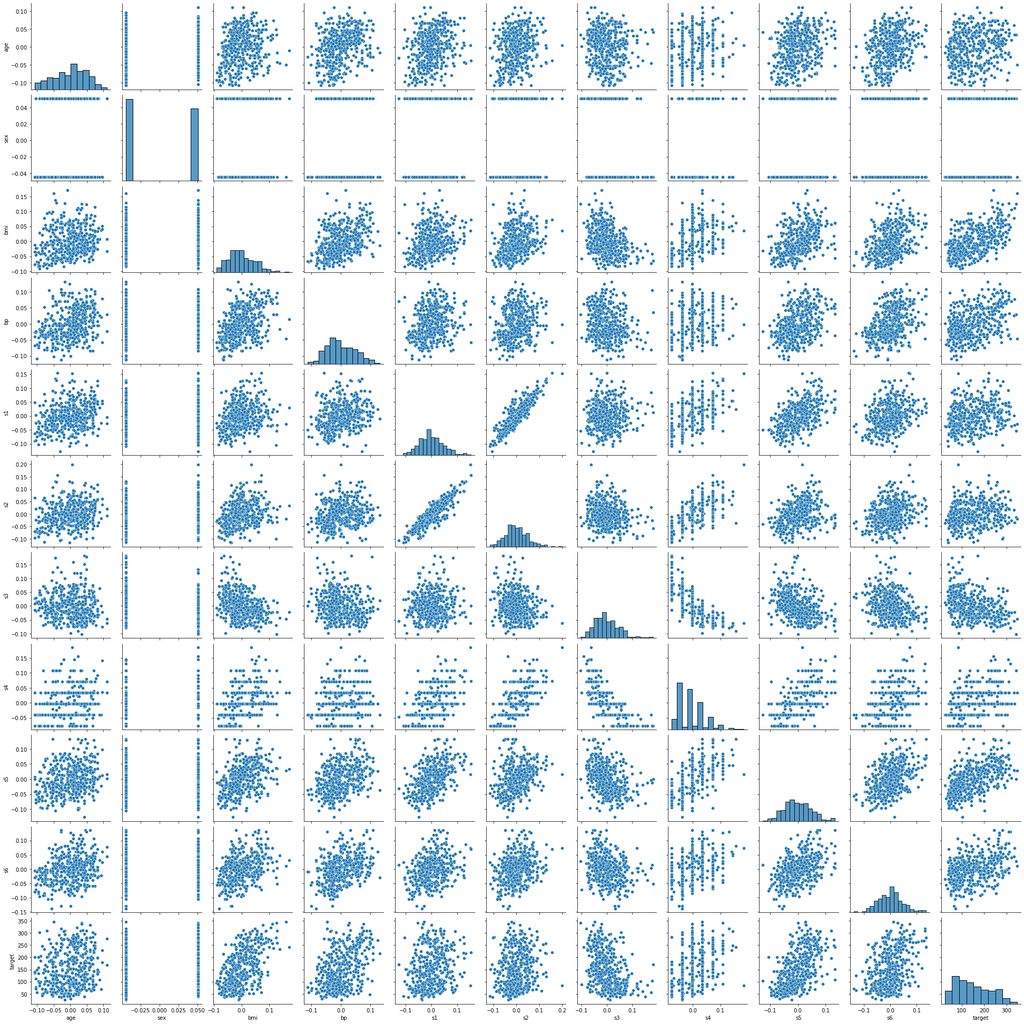

```python
sb.pairplot(data = d)
```

| 변수 | 설명 | 자료형태 |
| --- | --- | --- |
| Age | 연령 | 범주형 |
| sex | 성별 | 범주형 |
| bmi | 체질량지수 | 연속형 |
| bp | 평균 혈압 | 연속형 |
| $S_1, \dots, S_6$ | 6가지 혈청의 양 | 연속형 |

(4) 적합된 선형모형의 유의성에 대해 말하여라. 회귀계수가 유의한 설명변수들을 모두 찾아라.

(6) (3)에서 적합한 모형의 잔차도와 분위수 대조도를 그려보아라.

```python
fat=ols(formula='target~age+bmi+bp+s1+s2+s3+s4+s5+s6', data=d).fit()

print(fat.summary())

# from sklearn.datasets import load_boston
# bos = load_boston()
```

```
                            OLS Regression Results
==============================================================================
Dep. Variable:                 target   R-squared:                       0.501
Model:                            OLS   Adj. R-squared:                  0.490
Method:                 Least Squares   F-statistic:                     48.11
Date:                Sun, 02 Jan 2022   Prob (F-statistic):           8.80e-60
Time:                        02:16:36   Log-Likelihood:                -2393.7
No. Observations:                 442   AIC:                             4807.
Df Residuals:                     432   BIC:                             4848.
Df Model:                           9
Covariance Type:            nonrobust
==============================================================================
                 coef    std err          t      P>|t|      [0.025      0.975]
------------------------------------------------------------------------------
Intercept    152.1335      2.618     58.105      0.000     146.987     157.280
age          -33.1791     60.435     -0.549      0.583    -151.962      85.604
bmi          557.0556     66.936      8.322      0.000     425.495     688.617
bp           276.0860     65.307      4.227      0.000     147.727     404.445
s1          -712.8060    423.044     -1.685      0.093   -1544.287     118.675
s2           420.5672    344.309      1.221      0.223    -256.162    1097.296
s3           139.5107    215.802      0.646      0.518    -284.641     563.662
s4           126.2804    163.605      0.772      0.441    -195.280     447.841
s5           756.3691    174.728      4.329      0.000     412.947    1099.791
s6            48.9170     66.895      0.731      0.465     -82.563     180.397
==============================================================================
Omnibus:                        5.600   Durbin-Watson:                   2.018
Prob(Omnibus):                  0.061   Jarque-Bera (JB):                4.045
Skew:                           0.094   Prob(JB):                        0.132
Kurtosis:                       2.571   Cond. No.                         227.
==============================================================================

Notes:
[1] Standard Errors assume that the covariance matrix of the errors is correctly specified.
```

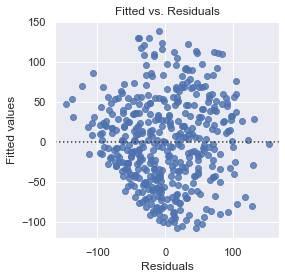

```python
# 1. 잔차도(residual plot): Residuals vs. Fitted

f = fat.fittedvalues              # 적합값 (fitted values)
r = fat.resid                     # 잔차 (residuals)
ar = np.abs(r)                      # 잔차의 절대값 (absolute residuals)

# ar_sort = ar.sort_values(ascending = False)
# top_3_ar = ar_sort[0:3]             # top 3 absolute residuals

sb.set(rc={'figure.figsize':(4,4)})
sb.residplot(r, f, data = d)

plt.title("Fitted vs. Residuals")
plt.ylabel("Fitted values")
plt.xlabel("Residuals")

# for i in top_3_ar.index:
#     plt.annotate(i, xy = (f[i], r[i]))  # 잔차의 절대값이 큰 관측값 3개를 그래프에 표시
plt.show()
```

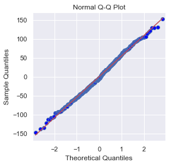

```python
# 2. 정규 분위수 (Normal Q-Q plot)

QQ = ProbPlot(r)
plot = QQ.qqplot(line = 's', color='C0', lw=1)
plt.title("Normal Q-Q Plot")

plt.show()
```

### (2) 범주형 설명변수 sex를 포함시켜 회귀분석을 실시해 보자.

| 변수 | 설명 | 자료형태 |
| --- | --- | --- |
| Age | 연령 | 범주형 |
| sex | 성별 | 범주형 |
| bmi | 체질량지수 | 연속형 |
| bp | 평균 혈압 | 연속형 |
| $S_1, \dots, S_6$ | 6가지 혈청의 양 | 연속형 |

(7) (3)의 모형에 sex 변수를 포함하여 선형회귀분석을 실시하라. (전처리 필요)

(8) 적합된 선형모형의 유의성에 대해 말하여라. 회귀계수가 유의한 설명변수들을 모두 찾아라. (4)에서의 결과와 다른 점이 있는지 말하여라.

(9) (7)에서 적합한 모형의 잔차도와 분위수 대조도를 그려보아라.

```python
# 전처리
from sklearn import preprocessing
L= preprocessing.LabelEncoder()
d["sex"]=L.fit_transform(d["sex"]).astype(str)

# fitting
fatge=ols(formula='target~age+bmi+bp+s1+s2+s3+s4+s5+s6+sex', data=d).fit()

print(fatge.summary())
```

```
                            OLS Regression Results
==============================================================================
Dep. Variable:                 target   R-squared:                       0.518
Model:                            OLS   Adj. R-squared:                  0.507
Method:                 Least Squares   F-statistic:                     46.27
Date:                Sun, 02 Jan 2022   Prob (F-statistic):           3.83e-62
Time:                        02:17:53   Log-Likelihood:                -2386.0
No. Observations:                 442   AIC:                             4794.
Df Residuals:                     431   BIC:                             4839.
Df Model:                          10
Covariance Type:            nonrobust
==============================================================================
                 coef    std err          t      P>|t|      [0.025      0.975]
------------------------------------------------------------------------------
Intercept    162.8394      3.756     43.359      0.000     155.458     170.221
sex[T.1]     -22.8600      5.836     -3.917      0.000     -34.330     -11.390
age          -10.0122     59.749     -0.168      0.867    -127.448     107.424
bmi          519.8398     66.534      7.813      0.000     389.069     650.610
bp           324.3904     65.422      4.958      0.000     195.805     452.976
s1          -792.1842    416.684     -1.901      0.058   -1611.169      26.801
s2           476.7458    339.035      1.406      0.160    -189.621    1143.113
s3           101.0446    212.533      0.475      0.635    -316.685     518.774
s4           177.0642    161.476      1.097      0.273    -140.313     494.442
s5           751.2793    171.902      4.370      0.000     413.409    1089.150
s6            67.6254     65.984      1.025      0.306     -62.065     197.316
==============================================================================
Omnibus:                        1.506   Durbin-Watson:                   2.029
Prob(Omnibus):                  0.471   Jarque-Bera (JB):                1.404
Skew:                           0.017   Prob(JB):                        0.496
Kurtosis:                       2.726   Cond. No.                         256.
==============================================================================

Notes:
[1] Standard Errors assume that the covariance matrix of the errors is correctly specified.
```

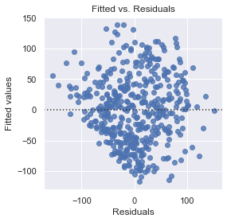

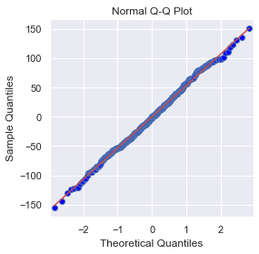

```python
f = fatge.fittedvalues
r = fatge.resid
ar = np.abs(r)

sb.set(rc={'figure.figsize':(4,4)})
sb.residplot(r, f, data = d)

plt.title("Fitted vs. Residuals")
plt.ylabel("Fitted values")
plt.xlabel("Residuals")

plt.show()

QQ = ProbPlot(r)
plot = QQ.qqplot(line = 's', color='C0', lw=1)
plt.title("Normal Q-Q Plot")

plt.show()
```

### (3) sex 값을 기준으로 데이터를 분리하여 회귀분석을 실시해 보자.

| 변수 | 설명 | 자료형태 |
| --- | --- | --- |
| Age | 연령 | 범주형 |
| sex | 성별 | 범주형 |
| bmi | 체질량지수 | 연속형 |
| bp | 평균 혈압 | 연속형 |
| $S_1, \dots, S_6$ | 6가지 혈청의 양 | 연속형 |

(10) sex변수의 값이 1인 표본과 0인 표본을 분리하라. 각 데이터에 대해 (sex를 제외한) 모든 설명변수를 포함하여 선형회귀분석을 실시하라.

(11) 적합된 선형모형들의 유의성에 대해 말하여라. 각 모형에서 회귀계수가 유의한 설명변수들을 모두 찾아라. (4),(8)에서의 결과와 다른 점이 있는지 말하여라.

(13) 두 선형모형 적합결과와 (3)에서 보았던 선형모형을 비교해 보자. (7),(8)에서의 접근과 (10),(11)에서의 접근이 어떤 차이를 가지고 있는지 생각해보자.

```python
d1=d[d.sex=='1']
d0=d[d.sex=='0']

fat1=ols(formula='target~age+bmi+bp+s1+s2+s3+s4+s5+s6', data=d1).fit()
fat0=ols(formula='target~age+bmi+bp+s1+s2+s3+s4+s5+s6', data=d0).fit()

print(fat1.summary())
```

```
                            OLS Regression Results
==============================================================================
Dep. Variable:                 target   R-squared:                       0.600
Model:                            OLS   Adj. R-squared:                  0.582
Method:                 Least Squares   F-statistic:                     32.88
Date:                Sun, 02 Jan 2022   Prob (F-statistic):           8.78e-35
Time:                        02:18:51   Log-Likelihood:                -1101.3
No. Observations:                 207   AIC:                             2223.
Df Residuals:                     197   BIC:                             2256.
Df Model:                           9
Covariance Type:            nonrobust
==============================================================================
                 coef    std err          t      P>|t|      [0.025      0.975]
------------------------------------------------------------------------------
Intercept    139.4394      4.110     33.929      0.000     131.335     147.544
age          176.9132     79.822      2.216      0.028      19.499     334.328
bmi          649.7105     97.089      6.692      0.000     458.243     841.178
bp           388.8204     95.645      4.065      0.000     200.201     577.440
s1          -509.0035    545.123     -0.934      0.352   -1584.029     566.022
s2           173.2422    430.907      0.402      0.688    -676.541    1023.026
s3           142.7561    324.466      0.440      0.660    -497.117     782.629
s4           205.7184    225.587      0.912      0.363    -239.157     650.593
s5           621.1362    223.804      2.775      0.006     179.776    1062.496
s6           117.1617     89.823      1.304      0.194     -59.976     294.299
==============================================================================
Omnibus:                        6.835   Durbin-Watson:                   1.988
Prob(Omnibus):                  0.033   Jarque-Bera (JB):                5.791
Skew:                           0.325   Prob(JB):                       0.0553
Kurtosis:                       2.500   Cond. No.                         219.
==============================================================================

Notes:
[1] Standard Errors assume that the covariance matrix of the errors is correctly specified.
```

```python
print(fat0.summary())
```

```
                            OLS Regression Results
==============================================================================
Dep. Variable:                 target   R-squared:                       0.486
Model:                            OLS   Adj. R-squared:                  0.466
Method:                 Least Squares   F-statistic:                     23.66
Date:                Sun, 02 Jan 2022   Prob (F-statistic):           3.37e-28
Time:                        02:18:53   Log-Likelihood:                -1272.1
No. Observations:                 235   AIC:                             2564.
Df Residuals:                     225   BIC:                             2599.
Df Model:                           9
Covariance Type:            nonrobust
==============================================================================
                 coef    std err          t      P>|t|      [0.025      0.975]
------------------------------------------------------------------------------
Intercept    162.8576      4.062     40.088      0.000     154.852     170.863
age         -154.8565     88.182     -1.756      0.080    -328.625      18.913
bmi          409.0883     89.705      4.560      0.000     232.318     585.858
bp           299.6069     88.269      3.394      0.001     125.667     473.546
s1         -1482.7098    642.511     -2.308      0.022   -2748.819    -216.601
s2          1083.0291    527.029      2.055      0.041      44.484    2121.574
s3           334.2219    300.793      1.111      0.268    -258.510     926.954
s4           305.1636    250.908      1.216      0.225    -189.266     799.594
s5          1005.3781    260.069      3.866      0.000     492.896    1517.860
s6             4.9124     94.613      0.052      0.959    -181.528     191.353
==============================================================================
Omnibus:                        1.149   Durbin-Watson:                   2.102
Prob(Omnibus):                  0.563   Jarque-Bera (JB):                1.178
Skew:                          -0.167   Prob(JB):                        0.555
Kurtosis:                       2.904   Cond. No.                         248.
==============================================================================

Notes:
[1] Standard Errors assume that the covariance matrix of the errors is correctly specified.
```

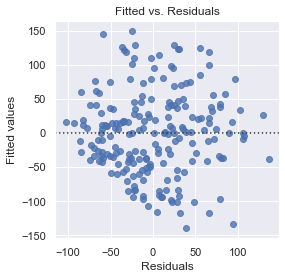

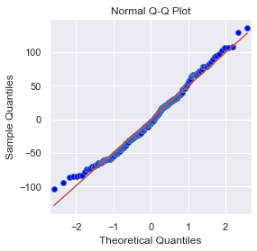

```python
f = fat1.fittedvalues
r = fat1.resid
ar = np.abs(r)

sb.set(rc={'figure.figsize':(4,4)})
sb.residplot(r, f, data = d)

plt.title("Fitted vs. Residuals")
plt.ylabel("Fitted values")
plt.xlabel("Residuals")

plt.show()

QQ = ProbPlot(r)
plot = QQ.qqplot(line = 's', color='C0', lw=1)
plt.title("Normal Q-Q Plot")

plt.show()
```